# Primer on fluorescenc microscopy & annotated reading of "Demonstration of Single Barium Ion Sensitivity for Neutrinoless Double Beta Decay using Single Molecule Fluorescence Imaging"

## Author

- J.J. Gomez-Cadenas [NEXT](https://next.ific.uv.es/next/)

#### Contact

- Email

# Primer on fluorescence microscopy

An introduction to fluorescence microscopy can be found [here](https://www.microscopyu.com/techniques/fluorescence/introduction-to-fluorescence-microscopy). In the next slides we summarize some of the key concepts.

1. Fundamentals of Excitation and Emission
2. Epi-fluorescence illumination
3. Steering of the ligth. FIlters
4. Stokes’ Shift
5. Extintion coefficient and quantum yield
6. Fading, Quenching, and Photobleaching
7. The Fluorescence Light Budget
8. Produced fluorescence
9. Dye concentration and emitted fluorescence
10. Efficiency of detection
11. Duration of fluorescence
12. Detected light
13. Detecting Single Molecules
14. TIRFM

## Fundamentals of Excitation and Emission

[figure not shown]

- Illustrated in figure is a cutaway diagram of a modern epi-fluorescence microscope equipped for both transmitted and reflected fluorescence microscopy.
- The vertical illuminator in the center of the diagram has the light source positioned at one end and the filter cube turret at the other.
- The design consists of a basic reflected light microscope in which the wavelength of the reflected light is longer than that of the excitation.
- In a fluorescence vertical illuminator, light of a specific wavelength is produced by passing multispectral light from an arc-discharge lamp through a wavelength selective excitation filter. Wavelengths passed by the excitation filter reflect from the surface of a dichromatic (also termed a dichroic) mirror or beamsplitter, through the microscope objective to bath the specimen with intense light.
- If the specimen fluoresces, the emission light gathered by the objective passes back through the dichromatic mirror and is subsequently filtered by a barrier (or emission) filter, which blocks the unwanted excitation wavelengths.

## Epi-fluorescence illumination

- In Epi-fluorescence illumination the reflected light vertical illuminator is interposed between the observation viewing tubes and the nosepiece housing the objectives. The illuminator is designed to direct light onto the specimen by first passing the excitation light through the microscope objective (which in this configuration, acts as a condenser) on the way toward the specimen, and then using that same objective to capture the emitted fluorescence.
- This type of illuminator has several advantages.

  a. The fluorescence microscope objective serves first as a well-corrected condenser and secondly as the image-forming light gatherer. Being a single component, the objective/condenser is always in perfect alignment.

  b. A majority of the excitation light reaching the specimen passes through without interaction and travels away from the objective, and the illuminated area is restricted to that which is observed through the eyepieces.

  c. The full numerical aperture of the objective is available when the microscope is properly configured.

## Steering of the ligth. FIlters

[figure not shown]

- Excitation light travels along the illuminator perpendicular to the optical axis of the microscope, passes through collector lenses and impinges upon the excitation filter where selection of the desired band and blockage of unwanted wavelength occurs.
- The selected wavelengths, after passing through the excitation filter, reach the dichromatic beamsplitting mirror, which reflects shorter wavelength light and passes longer wavelength light.
- The dichromatic beamsplitter is tilted at a 45-degree angle with respect to the incoming excitation light and reflects this illumination at a 90-degree angle directly through the objective optical system and onto the specimen.
- Fluorescence emission produced by the illuminated specimen is gathered by the objective, now serving in its usual image-forming function.
- Because the emitted light consists of longer wavelengths than the excitation illumination, it is able to pass through the dichromatic mirror and upward to the observation tubes or electronic detector.

## Stokes’ Shift

[figure not shown]

- Stokes' shift: the emission spectrum of an excited fluorophore is usually shifted to longer wavelengths when compared to the absorption or excitation spectrum. As Stokes' shift values increase, it becomes easier to separate excitation from emission light through the use of fluorescence filter combinations.
- In order to achieve maximum fluorescence intensity, a fluorophore (often termed a dye) is usually excited at wavelengths near or at the peak of the excitation curve, and the widest possible range of emission wavelengths that include the emission peak are selected for detection. The selection of excitation and emission wavelengths uses interference filters.

## Extintion coefficient and quantum yield

- The efficiency with which a particular fluorophore absorbs a photon of the excitation light is a function of the molecular cross-section, and the likelihood of absorption is known as the extinction coefficient. Larger extinction coefficients indicate that the absorption of a photon (or quantum) in a given wavelength region is more likely.
- The quantum yield denotes the ratio of the number of quanta emitted compared to those absorbed (and is usually a value between 0.1 and 1.0). Quantum yield values below 1 are the result of the loss of energy through nonradiative pathways, such as heat or a photochemical reaction, rather than the re-radiative pathway of fluorescence.

## Fading, quenching and photobleaching

- The general term for a reduction of fluorescence emission intensity is fading, a catch-all category that is usually further subdivided into quenching and photobleaching phenomena for more precise descriptions.
- Photobleaching is the irreversible decomposition of the fluorescent molecules in the excited state because of their interaction with molecular oxygen before emission.
- The excited state relaxation process of quenching results in reduced fluorescence intensity through a variety of mechanisms involving non-radiative energy loss and frequently occurs as a result of oxidizing agents or the presence of salts or heavy metals or halogen compounds.
- In some cases, quenching results from the transfer of energy to another molecule (termed the acceptor), which resides physically close to the excited fluorophore (the donor), a phenomenon known as fluorescence resonance energy transfer (FRET).

## The Fluorescence Light Budget

1. Excitation source: 75-Watt xenon arc-discharge lamp. When the lamp output is collected and directed through a 490-nanometer interference filter (having a 10-nanometer bandwidth and 75 percent transmission), about 2 milliWatts of light will pass through. After reflection by a 90-percent efficient dichromatic mirror, a light flux of 1.8 milliWatts enters the rear aperture of the microscope objective as the excitation beam.
2. With a 100x objective having a numerical aperture of 1.4, the area of the specimen illuminated will be of the order of 35 x 35 $\mu^2$.
3. The light flux on the specimen is then about 150 Watts per square centimeter, which corresponds to a flux density of $3.7 \times 10^{20}$ photons per square centimeter.

```python
s = (35*35 * micron * micron)
p = 1.8 * miliwatt / s
print(p/(watt/cm2))
```

```
146.93877551020407
```

```python
def energy_light(lamda: float)->float:
    """
    Return the energy of light of a given wavelenght (in natural units).
    Parameters:
        lambda: Wavelength of light

    """
    lnm = lamda / nm
    return ((1240)/ lnm)*eV


def n_photons_light(lamda: float, beam_energy: float)->float:
    """
    Return the number of photons in a beam of wavelength lambda and beam_energy
    Parameters:
        lambda      : Wavelength of light
        beam_energy : Energy of beam

    """
    return beam_energy / energy_light(lamda)


def n_photons_per_time_light(lamda: float, beam_power: float, time: float)->float:
    """
    Returns the number of photons per unit time in a beam of wavelength lambda with beam_power
    Parameters:
        lambda     : Wavelength in nm
        beam_power : Beam power
        time       : lenght of pulse

    """
    return beam_power * time / energy_light(lamda)
```

```python
lamda       = 490 * nm
beam_power  = 150 * watt  #per cm2!
time        = 1 * second
beam_energy = beam_power * time
print(f'The energy of light with lambda = {lamda/nm} nm is {energy_light(lamda)/eV} eV ')
print(f'The energy of light with lambda = {lamda/nm} nm is {energy_light(lamda)/joule} J')
print('Number of photons light of lambda {0:5.1f} nm and energy {1:5.1f} J:               = {2:5.1e}'.format(
lamda/nm, beam_energy / joule, n_photons_light(lamda, beam_energy)))
print('Number of photons in {0:5.1e}/sec light of lambda {1:5.1f} nm and power {2:5.1f} W: = {3:5.1e}'.format(
time/second, lamda/nm, beam_power / watt, n_photons_per_time_light(lamda, beam_power, time)))
```

```
The energy of light with lambda = 490.0 nm is 2.5306122448979593 eV
The energy of light with lambda = 490.0 nm is 4.0544895697959185e-19 J
Number of photons light of lambda 490.0 nm and energy 150.0 J:               = 3.7e+20
Number of photons in 1.0e+00/sec light of lambda 490.0 nm and power 150.0 W: = 3.7e+20
```

## Produced fluorescence

The fluorescence emission depends on:

1. The absorption and emission characteristics of the fluorophore.
2. Its concentration in the specimen.
3. The optical path length.
4. Tthe fluorescence produced (F) is then given by the equation:

$$ F = \sigma × Q × I$$

where σ is the molecular absorption cross-section, Q is the quantum yield, and I is the incident light flux. Assuming that fluorescein is the fluorophore, the absorption cross-section (σ) is 3 x 10 × E(-16) square centimeters per molecule, Q equals 0.99, resulting in a value for F of 100,000 photons per second per molecule.

```python
def max_flux_due_to_photobleach(case : str ='oxygenated')->float:
    """
    Return the max number of photons per molecule due to photobleaching
    Parameters:
        str       :
            takes values 'o' or 'oxygenated' for oxygenated atmosphere
            takes values 'd' or 'deoxygenated' for deoxygenated atmosphere

    """
    if case == 'oxygenated' or case == 'o':
        return 36000
    elif case == 'deoxygenated' or case == 'd':
        return 360000
    else:
        return 1e20  # an arbitrary large number


def fluorescence_per_molecule(sigma: float, Q: float, I: float, time: float, case :str ='')->float:
    """
    Returns the number of photons per molecule emitted by fluorescence.
    Parameters:
        sigma       : absorption cross section per molecule
        beam_energy : Q quantum yield of molecule
        I           : beam power per unit surface
        time        : time of pulse

    """
    return min(sigma * Q * I, max_flux_due_to_photobleach(case))
```

```python
sigma_fl = 3E-16 * cm2
Q        = 1
I        = n_photons_per_time_light(lamda, beam_power, time) / cm2
print('Fluorescence per molecule and second = {0:5.1e}'.format(fluorescence_per_molecule(sigma_fl, Q, I, time)))
```

```
Fluorescence per molecule and second = 1.1e+05
```

## Dye concentration and emitted fluorescence

1. If the dye concentration is 1 micromole per liter and is uniformly distributed in a 40-micrometer diameter disk with a thickness of 10 micrometers (volume equal to 12 picoliters), there are approximately 7.6 million molecules in the optical path.
2. If all of the molecules were excited simultaneously, the fluorescence emission rate would be $8.4 \times 10^{11}$ photons per second (given the product of F and the number of dye molecules)

```python
Avogadro = 6.023E+23
def n_molecules(dye_concentration: float, dye_volume: float)->float:
    """
    Returns the number of molecules given a dye concentration and a dye volume
    Parameters:
        dye_concentration  : Concentration of dye
        dye_volume         : Volume of dye

    """
    return Avogadro * dye_concentration * dye_volume

dye_c  = 1 * micromole/l
dye_v  = np.pi * (40/2)**2 * 10 * micron3
print('nof molecules in path                         = {0:5.1e}'.format(n_molecules(dye_c, dye_v)))

print('nof photons in {0:5.1f} second emitted by sample = {1:5.1e}'.format(time/second,
      n_molecules(dye_c, dye_v) * fluorescence_per_molecule(sigma_fl, Q, I, time)))
```

```
nof molecules in path                         = 7.6e+06
nof photons in   1.0 second emitted by sample = 8.4e+11
```

## Efficiency of detection

1. The efficiency of detection is a function of the optical collection efficiency and the detector quantum efficiency.
2. A 1.4-numerical aperture objective with 100-percent transmission (an unrealistic condition) has a maximum collection efficiency, limited by the acceptance angle of about 30 percent.
3. The transmission efficiency of the dichromatic mirror is 85 percent and that of the barrier filter is 80 percent. The overall collection efficiency is then about 20 percent.
4. If the detector is a conventional charge-coupled device (CCD), the quantum efficiency is about 50 percent for the green fluorescein emission (at 525 nanometers), so the detected signal would be 86 billion photons per second or about 10 percent of the emitted fluorescence.

```python
def light_transmission_efficiency(na: float = 1.4, m: float = 100)->float:
    """
    Return the light transmission efficiency of an optical system with numerical aperture NA and magnification M
    Parameters:
        ma  : Numerical aperture
        m   : magnification

    """
    na1 = 1.4
    m1  = 100
    t1  = 0.3

    f1 = na / na1
    f2 = m / m1

    return t1 * (f1/f2)**2

NA = 1.4
M =  100
print(' for NA = {0:5.1f}, M = {1:5.1f}: T = {2:5.1f}'.format(
      NA, M, light_transmission_efficiency(NA, M) ))

NA = 0.7
M =  100
print(' for NA = {0:5.1f}, M = {1:5.1f}: T = {2:5.1f}'.format(
      NA, M, light_transmission_efficiency(NA, M) ))
```

```
 for NA =   1.4, M = 100.0: T =   0.3
 for NA =   0.7, M = 100.0: T =   0.1
```

```python
def filter_and_ccd_efficiency(eff_dm: float = 0.85, eff_f: float = 0.8, eff_ccd : float = 0.5)->float:
    """
    Returns the efficiency of filters and CCD
    Parameters:
        eff_dm  : efficiency of dicroic mirror
        eff_f   : efficiency of selection filter
        ef_ccd  : efficiency CCD

    """
    return eff_dm * eff_f * eff_ccd

print(f'Filter and CCD efficiency = {filter_and_ccd_efficiency()}')
```

```
Filter and CCD efficiency = 0.34
```

```python
overall_detection_efficiency = light_transmission_efficiency() * filter_and_ccd_efficiency()
nof_photons = n_molecules(dye_c, dye_v) * fluorescence_per_molecule(sigma_fl,
                                                                    Q, I, time) * overall_detection_efficiency
print('Overall detection efficiency          = {0:5.2f}'.format(overall_detection_efficiency))
print('Number of detected photons per second = {0:5.1e}'.format(nof_photons))
```

```
Overall detection efficiency          =  0.10
Number of detected photons per second = 8.6e+10
```

## Duration of fluorescence

1. The duration of fluorescence emission depends upon the rate of fluorophore destruction as a result of photobleaching.
2. For fluorescein in an oxygenated saline solution, measurements indicate that each molecule can only emit about 36,000 photons before being destroyed.
3. In a deoxygenated environment, the rate of photodestruction diminishes about tenfold, so 360,000 photons are produced per fluorescein molecule.
4. The entire dye pool, in this example (7.6 million molecules), would then be capable of producing a minimum of 2.6 x 10 × E(11) and a maximum of 2.6 x 10 × E(12) photons.
5. Assuming the emission rate of 100,000 photons per second per molecule calculated above, fluorescence could continue for only 0.3 to 3 seconds before photodestruction.

```python
def duration_of_fluorescence(sigma: float, Q: float, I: float, time: float, case :str ='')->float:
    """
    Returns the duration of fluorescence due to photobleaching
    Parameters:
        eff_dm  : efficiency of dicroic mirror
        eff_f   : efficiency of selection filter
        ef_ccd  : efficiency CCD

    """

    cases =['o','d','oxygenated','deoxigenated']
    if case in cases:
        return (max_flux_due_to_photobleach(case) / fluorescence_per_molecule(sigma, Q, I, time, case=''))* second
    else:
        return 1e+20

print('duration of fluorescence in oxygenated environment = {0:5.1f} secon'.format(
duration_of_fluorescence(sigma_fl, Q, I, time, case='o') / second))
print('duration of fluorescence in deoxygenated environment = {0:5.1f} second'.format(
duration_of_fluorescence(sigma_fl, Q, I, time, case='d') / second))
```

```
duration of fluorescence in oxygenated environment =   0.3 secon
duration of fluorescence in deoxygenated environment =   3.2 second
```

## Detecting single molecules

1. It is often possible to detect the fluorescence emission from a single molecule, provided that the optical background and detector noise are sufficiently low.
2. As discussed above, a single fluorescein molecule could emit as many as 300,000 photons before it is destroyed by photobleaching.
3. Assuming a 20-percent collection and detection efficiency, about 60,000 photons would be detected. Using avalanche photodiode or electron multiplying CCD detectors for these experiments, investigators have been able to monitor the behavior of single molecules for many seconds and even minutes.
4. The major problem is adequate suppression of the optical background noise. Because many of the materials utilized in construction of microscope lenses and filters display some level of autofluorescence, efforts were initially directed toward the manufacture of very low fluorescence components.
5. However, it soon became evident that fluorescence microscopy techniques utilizing total internal reflection (TIR) provided the desired combination of low background and high excitation light flux.

## TIRFM

[figure not shown]

1. Total internal reflection fluorescence microscopy (TIRFM) takes advantage of the evanescent wave that is developed when light is totally internally reflected at the interface between two media having dissimilar refractive indices.
1. The principle employing an external light source is illustrated in Figure (a). In this technique, a beam of light (usually an expanded laser beam) is directed through a prism of high refractive index, such as glass or sapphire, which abuts a lower refractive index medium of glass or aqueous solution.
2. If the light is directed into the prism at higher than the critical angle, the beam will be totally internally reflected at the interface. The reflection phenomenon develops an evanescent wave at the interface by the generation of an electromagnetic field that permeates about 200 nanometers or less into the lower refractive index space. The light intensity in the evanescent wave is sufficiently high to excite the fluorophores within it, but because of its shallow depth, the volume excited is very small. The result is an extremely low-level background because so little of the specimen is exposed to the excitation light (only that portion within a 200-nanometer distance of the interface).
3. TIRF can also be conducted through a modification of the epi-illumination approached utilized in widefield techniques (as illustrated in Figure (b)). This method requires a very high numerical aperture objective (at least 1.4, but preferably 1.45 to 1.6) and partial illumination of the microscope field from one side by a small sport or more uniform illumination by a thin annulus. High refractive index lens immersion medium and microscope cover glass are required to achieve the illumination angle resulting in total internal reflection. As presented in Figure (b), light rays exiting the objective front lens element at an angle less than the critical angle (denoted as A(1)) in figure (b)) are transmitted away from the microscope. When the angle is increased to or beyond the critical angle (indicated a angle A(2) in Figure (b)), total internal reflection results.

# Demonstration of Single Barium Ion Sensitivity for Neutrinoless Double Beta Decay using Single Molecule Fluorescence Imaging

#### **A.D.McDonald et al, (The NEXT Collaboration)**

# Experiment

1. To demonstrate single Ba++ sensitivity we have imaged individual near-surface Ba++ ions from dilute barium salt solutions.
2. We use the technique of through-objective total internal reflection fluorescence (TIRF) microscopy. In through-objective TIRF, a high numerical aperture objective is used to convert a focused light beam on the back-focal plane (BFP) into parallel rays. By translating the focal point across the BFP, the emerging parallel rays are brought to a shallow angle, until eventually they totally internally reflect on the lower sample surface. The evanescent excitation wave, extending only about one wavelength into the sample, causes fluorescence of the near-surface molecules while minimizing deeper fluorescence and scattering from within the sample.
3. By focusing the objective on the same scanning surface and imaging the fluorescence light, individual fluorescent molecules can be spatially resolved above a dimmer, diffuse background.

## Setup

[figure not shown]

## Microscope

- The apparatus is an [Olympus IX-70 inverted fluorescence microscope frame](https://www.olympus-lifescience.com/en/microscope-resource/primer/techniques/fluorescence/ix70fluorescence/)
- The objective is an Olympus 100x 1.4 NA, and was used with Olympus immersion oil (n = 1.518).
- Low-fluorescence coverslips of thickness 0.13 mm serve the combined role of sample substrates and imaging plane.
- A Hamamatsu ImagEM X2 EM-CCD camera, was used to record the fluorescence emission.
- The excitation source is an NKT Photonics SuperK EXTREME laser, which emits in a wide spectral range of 350-2350 nm. The laser light is filtered to a tunable band of width ± 1 nm in the visible range via an acousto-optical tunable filter (AOTF). The beam is then expanded, cleaned, and steered via an array of adjustable mirrors through a lens that focuses it onto the objective BFP.
- Emission and excitation light are separated by a filter cube containing the dichroic mirror and emission and excitation filters.
- Micrometer stages in the external optical system allow for focusing on the BFP and adjustment of the TIRF ray angle, and the image is brought into focus using sample stage adjustment on the microscope frame.

## SAMPLE PREPARATION

- The studies use fluorophores that are immobilized at the sensor surface. This emulates the conditions in a HPGXe TPC detector, where the ions will drift to the sensor plate and adhere to fluorophores immobilized there.
- The chosen method was to use a matrix of polyvinyl alcohol (PVA) trapping the fluors but allowing permeability of ions through-out the sample.
- Coverslips were inspected for defects and cleaned by ultrasonic bath in acetone for 30 minutes and then ethanol for 30 minutes. Once clean, they were placed in a vacuum oven at 340 K to bake overnight. A buffer solution (pH 7.2) was established using ACS Ultra Trace water with imidazole and hydrochloric acid. PVA was added (5% by weight) to form the working buffer and placed in a hot water bath. Once the PVA is fully dissolved it is removed from the bath and set on a stir plate, with water added to reach the target volume. After 30 minutes the solution reaches room temperature and BAPTA is added to a concentration of 250 μM to suppress residual calcium.
- The SMFI fluor Fluo-3 is then added, to a concentration of 1 nM.
- Three background samples were made by placing 50 μL of solution onto a coverslip then spin coating it at 1800 rpm for 10 seconds. These will be referred to as the “barium-free” samples.
- Ba++ was then added in the form of barium perchlorate salt solution to a target concentration of 500 μM, to make three “barium-spiked” samples.
- All samples were placed in an oven at 340 K for 4 hours, and then left to cure overnight at room temperature, in order to harden the PVA matrix.

## Imaging

- Prior to scanning the samples, the AOTF was set to 488 nm, which is the peak excitation wavelength for Fluo-3.
- The measured power entering the objective was 1 μW.
- The external optics were adjusted to place the system into total internal reflection mode using prismatic alignment.
- Surface sensitivity was checked with fluorescent micro-spheres.
- Each sample was then placed onto the microscope stage and scanned.
- The imaging protocol was to find a 35x 35 μm2 Field of View (FOV) where at least one fluorescent spot was present, and focus the microscope on that spot by minimizing its point spread.
- Once focus was achieved, images were taken every 500 ms for 375 s.
- Then, a new FOV was found by randomly translating the sample stage and refocusing.

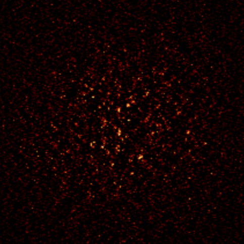

```python
Image("img/prlFOV.png")
```

```python
# Using TIRF one is scanning about 200 nm of the sample's thickness.
dye_v  = (35)**2 * 0.2 * micron3

# concentration of Fluo-3
dye_c  = 1 * nanomole/l
print('nof fluo-3 in path  = {0:5.1e}'.format(n_molecules(dye_c, dye_v)))

#concentration of Ba++
dye_b  = 500 * micromole/l
print('nof Ba++ in path    = {0:5.1e}'.format(n_molecules(dye_b, dye_v)))
```

```
nof fluo-3 in path  = 1.5e+02
nof Ba++ in path    = 7.4e+07
```

- Thus, the concentration of dye (fluo-3) molecules per FOV is very sparse. The concentration of Ba++ is five orders of magnitude larger, and therefore all molecules will trap Ba++.
- Next we compute the beam power per cm2 in a field of view of 35 x 35 $\mu^2$ and about 200 nm thickness.

```python
area = (35*35 * micron * micron)
p = 1 * microwatt  / area
print('beam power watt/cm2 = {0:5.2e} '.format(p/(watt/cm2)))
```

```
beam power watt/cm2 = 8.16e-02
```

- We now compute the fluorescence per molecule and second and the number of photons emitted per second by the sample.

```python
lamda      = 488 * nm
beam_power = 8.2E-2 * watt
time       = 1 * second
I          = n_photons_per_time_light(lamda, beam_power, time) / cm2
sigma_fl = 3E-16 * cm2
Q        = 1
nof_photons_sample_per_second = n_molecules(dye_c, dye_v) * fluorescence_per_molecule(sigma_fl, Q, I, time)
integrated_time = 0.5 * 375

print('Nof photons per second delivered to sample = {0:5.1e}'.format(I))
print('Fluorescence per molecule and second = {0:5.1e}'.format(fluorescence_per_molecule(sigma_fl, Q, I, time)))
print('Nof photons in {0:5.1f} second emitted by sample = {1:5.1e}'.format(time/second,
      nof_photons_sample_per_second))
print('Nof photons in integrated time emitted by sample = {0:5.1e}'.format(
      nof_photons_sample_per_second * integrated_time))
```

```
Nof photons per second delivered to sample = 2.0e+15
Fluorescence per molecule and second = 6.0e+01
Nof photons in   1.0 second emitted by sample = 8.9e+03
Nof photons in integrated time emitted by sample = 1.7e+06
```

- After focusing in a given molecule, the FOV is of the order of 250 x 250 nm

```python
area = (0.25 * 0.25 * micron * micron)
p = 1 * microwatt  / area
print('beam power watt/cm2 = {0:5.2e} '.format(p/(watt/cm2)))
```

```
beam power watt/cm2 = 1.60e+03
```

```python
beam_power      = 1.60e+03  * watt
beam_pulse      = 0.5 * second
integrated_time = 0.5 * 375

I          = n_photons_per_time_light(lamda, beam_power, beam_pulse) / cm2
nof_photons_sample_per_pulse = n_molecules(dye_c, dye_v) * fluorescence_per_molecule(sigma_fl, Q, I, beam_pulse)

print('Nof photons per second delivered to sample = {0:5.1e}'.format(I))
print('Fluorescence per molecule and second = {0:5.1e}'.format(fluorescence_per_molecule(sigma_fl, Q, I, time)))
print('Nof photons in {0:5.1f} second (beam pulse) emitted by sample = {1:5.1e}'.format(beam_pulse/second,
      nof_photons_sample_per_pulse))
print('Nof photons in integrated time emitted by sample = {0:5.1e}'.format(
      nof_photons_sample_per_pulse * integrated_time))
```

```
Nof photons per second delivered to sample = 2.0e+19
Fluorescence per molecule and second = 5.9e+05
Nof photons in   0.5 second (beam pulse) emitted by sample = 8.7e+07
Nof photons in integrated time emitted by sample = 1.6e+10
```

- The amount of light will be limited by photobleaching.
- In the case of oxygenated environment one finds:

```python
nof_photons_sample_per_pulse = n_molecules(dye_c, dye_v) * fluorescence_per_molecule(sigma_fl, Q, I,
                                                                                     beam_pulse,
                                                                                     case='o')
print('Fluorescence per molecule and second = {0:5.1e}'.format(fluorescence_per_molecule(sigma_fl, Q, I,
                                                                                         beam_pulse,
                                                                                         case='o')))
print('Nof photons in {0:5.1f} second emitted by sample = {1:5.1e}'.format(time/second,
      nof_photons_sample_per_pulse))
print('Nof photons in integrated time emitted by sample = {0:5.1e}'.format(
      nof_photons_sample_per_pulse * integrated_time))
```

```
Fluorescence per molecule and second = 3.6e+04
Nof photons in   1.0 second emitted by sample = 5.3e+06
Nof photons in integrated time emitted by sample = 1.0e+09
```

- In the case of deoxigenated environment:

```python
nof_photons_sample_per_pulse = n_molecules(dye_c, dye_v) * fluorescence_per_molecule(sigma_fl, Q, I,
                                                                                     beam_pulse,
                                                                                     case='d')
print('Fluorescence per molecule and second = {0:5.1e}'.format(fluorescence_per_molecule(sigma_fl, Q, I,
                                                                                         beam_pulse,
                                                                                         case='d')))
print('Nof photons in {0:5.1f} second emitted by sample = {1:5.1e}'.format(time/second,
      nof_photons_sample_per_pulse))
print('Nof photons in integrated time emitted by sample = {0:5.1e}'.format(
      nof_photons_sample_per_pulse * integrated_time))
```

```
Fluorescence per molecule and second = 3.6e+05
Nof photons in   1.0 second emitted by sample = 5.3e+07
Nof photons in integrated time emitted by sample = 1.0e+10
```

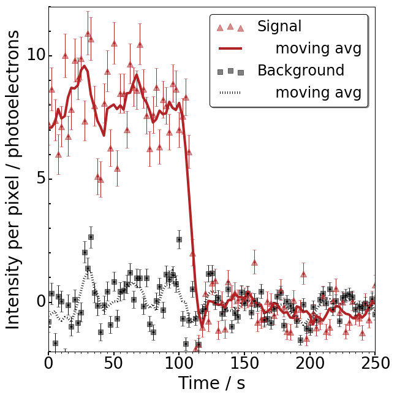

```python
Image("img/prlPhotobleaching.png")
```

```python
print('duration of fluorescence in oxygenated environment = {0:5.1f} second'.format(
duration_of_fluorescence(sigma_fl, Q, I, beam_pulse, case='o') / second))
print('duration of fluorescence in deoxygenated environment = {0:5.1f} second'.format(
duration_of_fluorescence(sigma_fl, Q, I, beam_pulse, case='d') / second))
```

```
duration of fluorescence in oxygenated environment =   0.1 secon
duration of fluorescence in deoxygenated environment =   0.6 second
```

- The time until photobleach depends on the conditions.
- The time until photobleach found in paper is much longer than predicted by tutorial. It may mean that the environment contains very little oxygen.

## Light recorded in the CCD

- Light goes through the optics with an efficiency of ~20 % and is recorded by a megapixel CCD.
- The number of photons per pixel is consistent with results obtained in PRL (very slow photobleaching)

```python
beam_power      = 1.60e+03  * watt
beam_pulse      = 0.5 * second
integrated_time = 0.5 * 375

I          = n_photons_per_time_light(lamda, beam_power, beam_pulse) / cm2
nof_photons_sample_per_pulse = n_molecules(dye_c, dye_v) * fluorescence_per_molecule(sigma_fl, Q, I, beam_pulse)

print('Nof photons in {0:5.1f} second (beam pulse) emitted by sample = {1:5.1e}'.format(beam_pulse/second,
      nof_photons_sample_per_pulse))
print('Nof photons in {0:5.1f} second (beam pulse) reaching CCD = {1:5.1e}'.format(beam_pulse/second,
      0.2* nof_photons_sample_per_pulse))
print('Nof photons in {0:5.1f} second (beam pulse) per pixel = {1:5.1e}'.format(beam_pulse/second,
      0.2* nof_photons_sample_per_pulse/1e+6))
```

```
Nof photons in   0.5 second (beam pulse) emitted by sample = 8.7e+07
Nof photons in   0.5 second (beam pulse) reaching CCD = 1.7e+07
Nof photons in   0.5 second (beam pulse) per pixel = 1.7e+01
```